# heartRateNormalModel

Bryan Milstead

December 1, 2016

## Background

Researchers at Pusan National University in Korea compared the cardiovascular fitness of marathon runners to a control group of non-athletes. Athletes and control group members had similar ages and weights. They found a dramatic difference in the resting heart rates (measured in beats per minute [bpm]) of the athletes compared to the control group. Marathon athletes (N=406) had a mean resting heart rate of 59.45bpm and a standard deviation of 4.26bpm. The control group (N=394) had a mean resting heart rate of 74.52bpm and a standard deviation of 9.15bpm.

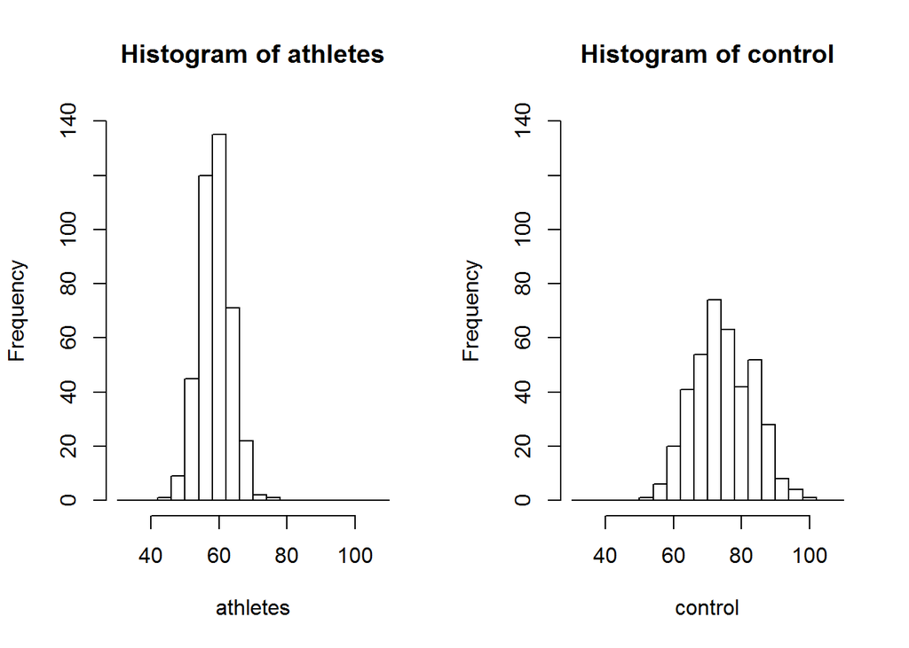

## Questions

- Is it appropriate to use the normal model to compare these two distributions? Yes / No
- Explain your answer.
- A nurse practicioner exams two patients from the above study. The first, a marathon runner, has resting heart rate of 71. The second patient is from the control group and has a resting heart rate of 90.
  - Calculate the Z scores for both patients
  - Which one has a higher resting heart rate compared to other members of their group (athletes vs. control)?
  - Explain what the Z score for the marathon runner means.